# A Sentimental Analysis of Tolstoy

Alex Salem

June 18, 2018

## Introduction

Goal: Create a graph showing sentiment analysis of three Tolstoy novels over his career.

Inspired by Julia Silge’s [sentiment analysis of Jane Austen novels](https://juliasilge.com/blog/life-changing-magic/).

Hypothesis: Tolstoy’s last novel, *Resurrection*, will have a different sentiment pattern than his others.

## Description of the Data

Full text of three novels by Leo Tolstoy:

- *Childhood* (1852), translated into English by C.J. Hogarth
- *Anna Karenina* (1877), translated into English by Constance Garnett
- *Resurrection* (1899), translated into English by Mrs. Louise Maude

Plaintext copies pulled from [Project Gutenburg.](http://www.gutenberg.org/)

Data cleaned and processed using `Python`:

```python
import csv
from nltk import word_tokenize

def clean(infilename, outfilename):
    title = outfilename[:-4]
    with open(infilename, "r") as f:
        text = f.read()

    tokens = word_tokenize(text)
    tokens = [w.lower() for w in tokens]
    print(tokens[:100])
    words = [word for word in tokens if word.isalpha()]
    print(words[:100])

    with open(outfilename, "w") as csvfile:
        writer = csv.writer(csvfile)
        writer.writerow(["title", "words"])
        for word in words:
            writer.writerow([title, word])

names = [["anna_karenina_clean.txt", "anna_karenina.csv"], ["boyhood_clean.txt", "boyhood.csv"],
        ["childhood_clean.txt", "childhood.csv"], ["cossacks_clean.txt", "cossacks.csv"],
        ["resurrection_clean.txt", "resurrection.csv"], ["war_and_peace_clean.txt", "war_and_peace.csv"],
        ["youth_clean.txt", "youth.csv"]]

for name in names:
    clean(name[0], name[1])
```

Then read into R.

Used the following libraries:

```r
library(readr)
library(tidytext)
library(tidyverse)
library(viridis)
```

Then read in the csvs:

```r
anna_karenina<- read_csv("anna_karenina.csv", col_types = cols(title = col_factor(levels = NULL)))
childhood <- read_csv("childhood.csv", col_types = cols(title = col_factor(levels = NULL)))
resurrection<- read_csv("resurrection.csv", col_types = cols(title = col_factor(levels = NULL)))
```

Added a column with the row number of each word:

```r
anna_karenina <- anna_karenina %>%
  rownames_to_column()

childhood <- childhood %>%
  rownames_to_column()

resurrection <- resurrection %>%
  rownames_to_column()
```

Then, combined rows into one data frame:

```r
data <- bind_rows(childhood, anna_karenina, resurrection)
```

```r
glimpse(data)
```

```
## Observations: 564,231
## Variables: 3
## $ rowname <chr> "1", "2", "3", "4", "5", "6", "7", "8", "9", "10", "11...
## $ title   <chr> "childhood", "childhood", "childhood", "childhood", "c...
## $ words   <chr> "the", "tutor", "karl", "ivanitch", "on", "the", "of",...
```

```r
head(data)
```

```
## # A tibble: 6 x 3
##   rowname title     words
##   <chr>   <chr>     <chr>
## 1 1       childhood the
## 2 2       childhood tutor
## 3 3       childhood karl
## 4 4       childhood ivanitch
## 5 5       childhood on
## 6 6       childhood the
```

The `tidytext::get_sentiments()` function assigns sentiment values to words:

```r
glimpse(get_sentiments("bing"))
```

```
## Observations: 6,788
## Variables: 2
## $ word      <chr> "2-faced", "2-faces", "a+", "abnormal", "abolish", "...
## $ sentiment <chr> "negative", "negative", "positive", "negative", "neg...
```

## First Visualization

Creating the data frame:

```r
bad_data <- data %>%
  inner_join(get_sentiments("bing"), by = c("words" = "word")) %>%
  count(title, index = as.numeric(rowname)%/%2000, sentiment) %>%
  spread(sentiment, n, fill = 0) %>%
  mutate(sentiment = positive - negative)

bad_plot<- ggplot(bad_data, aes(index, sentiment, fill = title)) +
  geom_bar(stat = "identity", show.legend = FALSE) +
  facet_wrap(~title, ncol = 3, scales = "free_x")
```

- Join sentiment values (either “positive” or “negative”) to words in `data`
- Count number of positive and negative words, per 2000 words
- Calculate the difference between those counts, per 2000 words

```r
head(bad_data)
```

```
## # A tibble: 6 x 5
##   title         index negative positive sentiment
##   <chr>         <dbl>    <dbl>    <dbl>     <dbl>
## 1 anna_karenina     0       68       63        -5
## 2 anna_karenina     1       66       72         6
## 3 anna_karenina     2       93       56       -37
## 4 anna_karenina     3       43       83        40
## 5 anna_karenina     4       43       74        31
## 6 anna_karenina     5       44       55        11
```

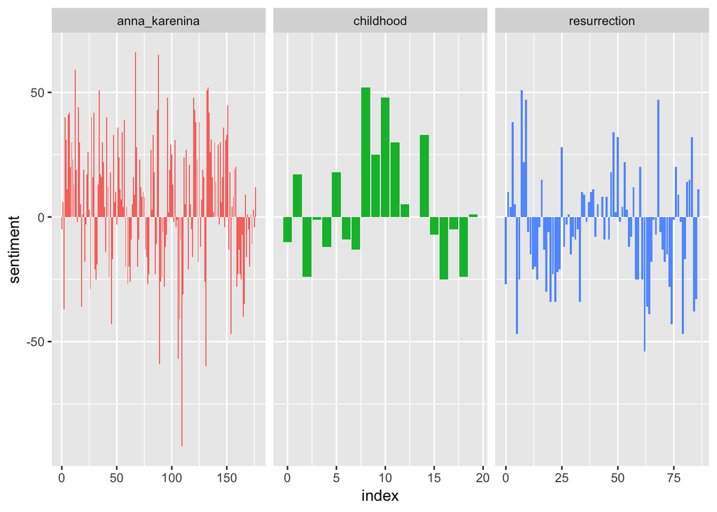

```r
bad_plot
```

## Description of the Data

```r
data_final<- data %>%
  group_by(title) %>%
  inner_join(get_sentiments("bing"), by = c("words" = "word")) %>%
  count(title, index = as.numeric(rowname)%/%max(as.numeric(rowname)/40), sentiment) %>%
  filter(as.numeric(index)!=40) %>%
  spread(sentiment, n, fill = 0) %>%
  mutate(sentiment = positive/(positive+negative))

data_final$title<- fct_relevel(data_final$title, "childhood")
```

- Join sentiment values (either “positive” or “negative”) to words in `data`
- Divide data into 40 sections, count number of positive and negative words in each section
- Calculate the ratio of positive words to positive and negative words

```r
head(data_final)
```

```
## # A tibble: 6 x 5
## # Groups:   title [1]
##   title         index negative positive sentiment
##   <fct>         <dbl>    <dbl>    <dbl>     <dbl>
## 1 anna_karenina     0      289      300     0.509
## 2 anna_karenina     1      222      350     0.612
## 3 anna_karenina     2      230      375     0.620
## 4 anna_karenina     3      224      317     0.586
## 5 anna_karenina     4      299      256     0.461
## 6 anna_karenina     5      272      308     0.531
```

## Methods

- Use `fct_relevel()` (above) to order the books to be facetted by year
- Use `geom_point()`, `geom_hline()`, and `geom_segment()` to create the lollipops
- `facet_wrap()` by title, relabel with nice names
- Add axis labels and title/subtitle
- Change colors and legend

```r
labels <- c(childhood = "Childhood, 1852", anna_karenina = "Anna Karenina, 1877", resurrection = "Resurrection, 1899")

plot <- ggplot(data_final, aes(index, sentiment, color =  title)) +
  geom_point(size = .8, show.legend = FALSE) +
  geom_hline(aes(yintercept=.5))+
  geom_segment(aes(x=index, xend = index, y = sentiment, yend = .5)) +
  facet_wrap(~title, ncol = 3, labeller = labeller(title = labels)) +
  ggtitle("Positive and Negative Sentiment in Tolstoy Novels across Plot Trajectory", subtitle = "Sentiment Ratio = Positive Words / (Positive Words + Negative Words) \nSentiment Ratio > 0.5 indicates more positive than negative words \nSentiment Ratio < 0.5 indicates more negative than positive words      ") +
  labs(x = "Plot Trajectory", y = "Sentiment Ratio")+
  expand_limits(y=c(0,1)) +
  scale_color_viridis(discrete = TRUE, name = "Book", labels = labels) +
  theme_minimal() +
  theme(strip.text = element_text(face = "italic")) +
  theme(axis.ticks.x=element_blank()) +
  theme(axis.text.x=element_blank()) +
  theme(legend.position = "bottom")
```

## The plot

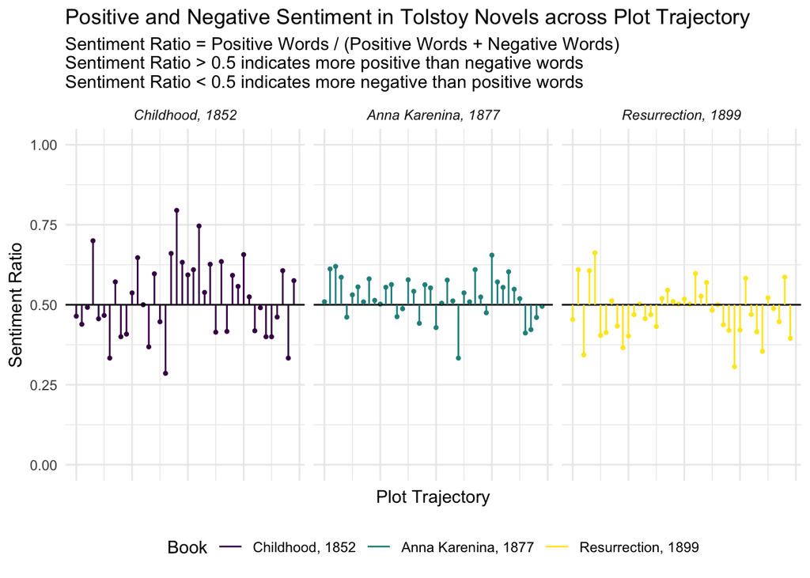

```r
plot
```

## Edited Version

### Steven’s q:

Investigating Steven’s q on what percentage of words have a sentiment, if there are any that are the most common:

```r
steve_q <- data %>%
  group_by(title) %>%
  inner_join(get_sentiments("bing"), by = c("words" = "word"))

steve_q
```

```
## # A tibble: 34,315 x 4
## # Groups:   title [?]
##    rowname title     words     sentiment
##    <chr>   <chr>     <chr>     <chr>
##  1 22      childhood wonderful positive
##  2 66      childhood saint     positive
##  3 77      childhood dead      negative
##  4 79      childhood fell      negative
##  5 101     childhood dead      negative
##  6 141     childhood soft      positive
##  7 175     childhood disturb   negative
##  8 182     childhood killing   negative
##  9 217     childhood tease     negative
## 10 222     childhood well      positive
## # ... with 34,305 more rows
```

```r
steve_q %>%
  filter(title == "childhood") %>%
  count(words, sort = TRUE)
```

```
## # A tibble: 907 x 3
## # Groups:   title [1]
##    title     words       n
##    <chr>     <chr>   <int>
##  1 childhood well       81
##  2 childhood love       72
##  3 childhood good       40
##  4 childhood like       32
##  5 childhood smile      27
##  6 childhood great      26
##  7 childhood grief      24
##  8 childhood poor       21
##  9 childhood darling    19
## 10 childhood enough     17
## # ... with 897 more rows
```

```r
steve_q %>%
  filter(title == "anna_karenina") %>%
  count(words, sort = TRUE)
```

```
## # A tibble: 2,319 x 3
## # Groups:   title [1]
##    title         words       n
##    <chr>         <chr>   <int>
##  1 anna_karenina well      627
##  2 anna_karenina like      516
##  3 anna_karenina love      426
##  4 anna_karenina good      328
##  5 anna_karenina smile     328
##  6 anna_karenina right     258
##  7 anna_karenina work      257
##  8 anna_karenina better    228
##  9 anna_karenina great     206
## 10 anna_karenina smiling   177
## # ... with 2,309 more rows
```

```r
steve_q %>%
  filter(title == "resurrection") %>%
  count(words, sort = TRUE)
```

```
## # A tibble: 1,680 x 3
## # Groups:   title [1]
##    title        words        n
##    <chr>        <chr>    <int>
##  1 resurrection well       293
##  2 resurrection like       217
##  3 resurrection prison     200
##  4 resurrection right      169
##  5 resurrection good       163
##  6 resurrection love       123
##  7 resurrection smile      112
##  8 resurrection advocate   101
##  9 resurrection prisoner    97
## 10 resurrection work        82
## # ... with 1,670 more rows
```

“Well” is the most common world–in the future, could take that word out and look at the results.

Total of 34315 words with a sentiment value in the data, which is 6% of the words.

### How can we improve this?

Ideas: - Legend at the bottom is repetitive - Add annotations– what’s happening in these various sections?

Implementation: - Add in `theme(legend.position = "none")` - Add a `text` variable and `geom_text()` layer

### What happens in different sections?

Word number 332681 total 353452 332681/353452 = x/40 .941 37/40 so 37th section is when Anna killed herself.

what’s in 25/40 -> .625 220907 to 229744 Karenin upset, Anna missing son.

Beginning, new love, Vronsky and Levin meeting again, etc.

Adding that info to data frame:

```r
data_final_2 <- data_final %>%
  mutate(text = "")

data_final_2$text = c(" ", " ", "New \nlove", rep(" ", 21),"Karenin \nupset, \nAnna missing \nson", rep(" ", 11), "Anna \nDies", rep(" ", 83))
```

Making a new plot, remove legend and add `geom_text()` layer:

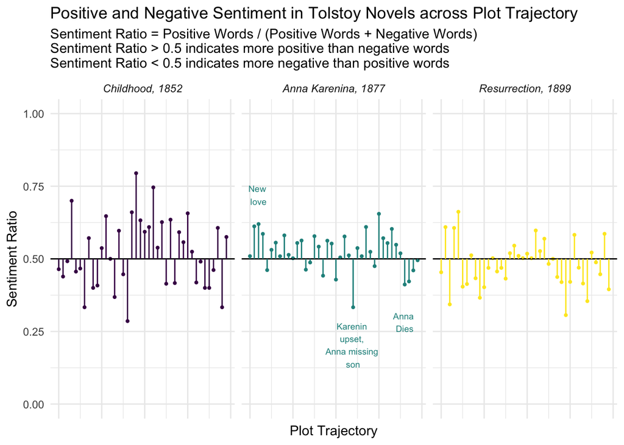

```r
plot_2 <- ggplot(data_final_2, aes(index, sentiment, color =  title, label = text)) +
  geom_point(size = .8, show.legend = FALSE) +
  geom_hline(aes(yintercept=.5))+
  geom_segment(aes(x=index, xend = index, y = sentiment, yend = .5)) +
  facet_wrap(~title, ncol = 3, labeller = labeller(title = labels)) +
  ggtitle("Positive and Negative Sentiment in Tolstoy Novels across Plot Trajectory", subtitle = "Sentiment Ratio = Positive Words / (Positive Words + Negative Words) \nSentiment Ratio > 0.5 indicates more positive than negative words \nSentiment Ratio < 0.5 indicates more negative than positive words      ") +
  labs(x = "Plot Trajectory", y = "Sentiment Ratio")+
  expand_limits(y=c(0,1)) +
  scale_color_viridis(discrete = TRUE, name = "Book", labels = labels) +
  theme_minimal() +
  theme(strip.text = element_text(face = "italic")) +
  theme(axis.ticks.x=element_blank()) +
  theme(axis.text.x=element_blank()) +
  theme(legend.position = "none") +
  geom_text(size = 2.5, aes(y = case_when(sentiment>.5 ~ sentiment + .1,
                                          sentiment <= .5 ~ sentiment -.13)))

plot_2
```

## Audience Description

I am aiming for a general audience–but hopefully readers of Tolstoy. :)

## Graph Type Description

This graph is a *lollipop plot*. A lollipop plot is a hybrid of a *scatter plot* and a *bar chart*.

It shows the relationship between a numeric variable and a categorical or numeric variable. It can also be used to highlight the distace from a certain value–here 0.5, indicating an equal number of positive and negative words.

## Representation Description

This plot shows the relationship between Sentiment Ratio and Plot Trajectory across three Tolstoy novels.

We can use this to get a sense of the “positivity” and “negativity” in Tolstoy’s novels over his career. In particular, we can see that *Childhood* and *Anna Karenina* are overall more positive than *Resurrection*.

## How to read it & what to look for

- Start by reading the title and x- and y- axes
- Then look for the baseline value the lollipops are extending from–here 0.5
- Look at one lollipop, interpret the meaning of that point
- Finally, analyze the general shape of the graph

## Presentation Description

Color is used here to distinguish between the three novels.

Additionally, the three novels are arranged by *year* the novel was written, with his earliest novel on the left, and his last novel on the right.

## References

https://machinelearningmastery.com/clean-text-machine-learning-python/

https://www.tidytextmining.com/sentiment.html

https://juliasilge.com/blog/life-changing-magic/

https://python-graph-gallery.com/lollipop-plot/